# Udacity Data Analyst Nanodegree | Project 5 | Communicate Data Findings - PISA DATA

## by Michelle Leemans

## What is PISA?

PISA is the OECD's Programme for International Student Assessment. PISA measures 15-year-olds’ ability to use their reading, mathematics and science knowledge and skills to meet real-life challenges.

## Investigation Overview

The aim of this project is to, firstly, explore the dataset using exploratory analysis.  
Second, explanatory analysis needs to be conducted in order to document the possible story telling.  
The third and last part of the project consists of the creation of a slide deck (current presentation). In this presentation 10 different questions are answered using the PISA dataset using univariate, bivariate and multivariate exploration of the data.

## Questions:

**Question 1** | What is the distribution of the scores for the different subjects among all the students?  
**Question 2** | What is male/female ratio of the pisa dataset?  
**Question 3** | What is the distribution of the data collection of the students among the different countries?  
**Question 4**| Which countries host the most "high scoring" students, what is the amount of students, with respect to each country and subject?  
**Question 5** | What is the male/female ratio of the students the highstest enrolled countries in the pisa study?  
**Question 6** | How are males/females scoring for the 3 different subjects?  
**Question 7** | What are the mean scores for students from different countries for the 3 different subjects?  
**Question 8** | What is the gender distribution in the top 90,95,99th percentile of students?  
**Question 9** | Are students who score high on one subject are likely to score high on another subject?  
**Question 10** | Does the highest degree of the parents have an influence on the mean scores of the student for the three individual subjects?

**Before starting the visualisation of the answers to the questions, the data needs first to be gathered, assessed and wrangeled in order to be used for the exploratory and explanatory analysis.**

### Visualization 1 | What is the distribution of the scores for the different subjects among all the students?

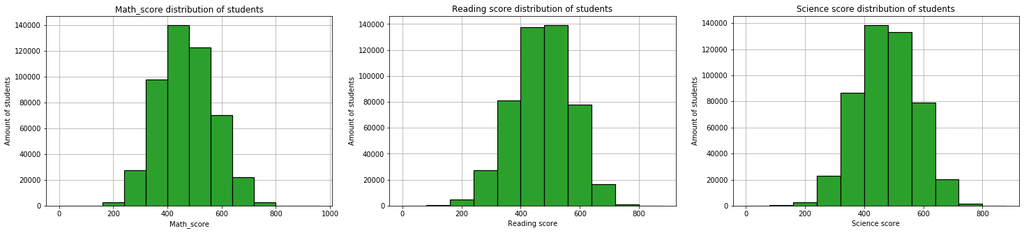

```python
plt.figure(figsize =[25,5])
base_color=sb.color_palette()[2]

axis = plt.subplot(1,3,1)
bin_edges = np.arange(0, df_clean['Math_score'].max()+80,80)
plt.hist(data = df_clean, x = 'Math_score', bins = bin_edges, edgecolor='black', linewidth=1.2, alpha = 1, color = base_color)
plt.grid(True);
plt.xlabel('Math_score')
plt.ylabel('Amount of students')
plt.title('Math_score distribution of students')
axis.set_axisbelow(True);

axis = plt.subplot(1,3,2)
bin_edges = np.arange(0, df_clean['Reading_score'].max()+80,80)
plt.grid(True)
plt.hist(data = df_clean, x = 'Reading_score', bins = bin_edges, edgecolor='black', linewidth=1.2, alpha = 1, color = base_color);
plt.xlabel('Reading score')
plt.ylabel('Amount of students')
plt.title('Reading score distribution of students');
axis.set_axisbelow(True);

axis = plt.subplot(1,3,3)
bin_edges = np.arange(0, df_clean['Science_score'].max()+80,80)
plt.hist(data = df_clean, x = 'Science_score', bins = bin_edges, edgecolor='black', linewidth=1.2, alpha = 1, color = base_color);
plt.xlabel('Science score')
plt.grid(True)
plt.ylabel('Amount of students')
plt.title('Science score distribution of students');
axis.set_axisbelow(True);
```

**Observation: The distribution of the scores of mathematics, reading and science among all the students in the Pisa study are normally distributed.**

### Visualization 2 | What is male/female ratio of the pisa dataset?

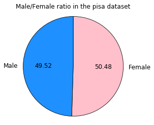

```python
labels = df_clean['Gender'].value_counts().index
plt.pie(df_clean['Gender'].value_counts(), labels = labels, startangle = 90,autopct='%1.2f',
       counterclock = False, textprops={'fontsize': 12},
           colors = ['pink','dodgerblue'], wedgeprops={"edgecolor":"k",'linewidth': 0.8});
plt.title('Male/Female ratio in the pisa dataset')
plt.axis('square');
```

**Observation: The male/female ratio is almost equal in the pisa dataset.**

### Visualization 3 | What is the distribution of the data collection of the students among the different countries?

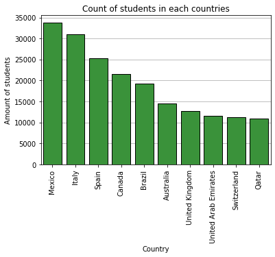

```python
base_color=sb.color_palette()[2]
order = df_clean['Country'].value_counts().iloc[:10].index
axis = plt.subplot(1,1,1)
sb.countplot(data = df_clean, x = 'Country', edgecolor='black', linewidth=1, alpha = 1, color = base_color, order = order)
plt.grid(True, axis = 'y');
plt.xlabel('Country')
plt.ylabel('Amount of students')
plt.title('Count of students in each countries')
plt.xticks(rotation=90)
axis.set_axisbelow(True);
```

**Observation: The highest amount of students within the Pisa study in 2012 comes from Mexico, followed by Italy, Spain and Canada.**

### Visualization 4 | Which countries host the most "high scoring" students, what is the amount of students, with respect to each country and subject?

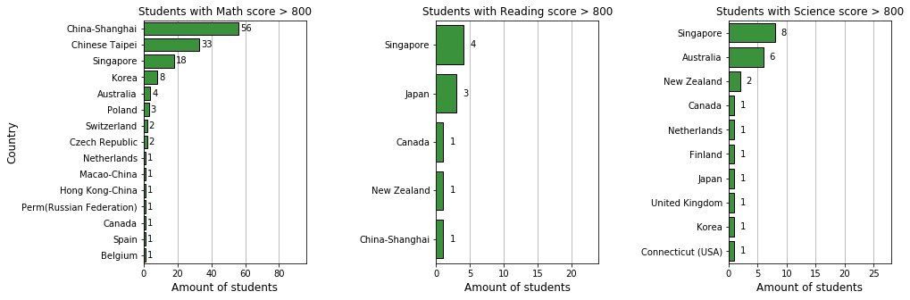

```python
plt.figure(figsize = [15, 5])
plt.subplots_adjust(wspace = 0.8)

#Plot 1 - Math score
axis = plt.subplot(1, 3, 1)

sb.barplot(data = df_clean, y = high_math_score.index, x = high_math_score.values, color = sb.color_palette()[2],
           edgecolor='black', linewidth=1)

plt.title('Students with Math score > 800', fontsize=12);
plt.xlabel('Amount of students', fontsize=12)
plt.ylabel('Country', fontsize=12);
x_lim_max = high_math_score.values[0] + 40
plt.xlim(0, x_lim_max);
plt.grid(axis='x');
axis.set_axisbelow(True);

indexes, labels = plt.yticks()
for index, label in zip(indexes, labels):
    plt.text(y = index, x = high_math_score[label.get_text()] + 1, s = high_math_score[label.get_text()], va = 'center')




#Plot 2 - Reading score
plt.subplot(1, 3, 2)
sb.barplot(y = high_reading_score.index, x = high_reading_score.values, color = sb.color_palette()[2]
          , edgecolor='black', linewidth=1)

plt.title('Students with Reading score > 800', fontsize=12);
plt.xlabel('Amount of students', fontsize=12);
x_lim_max = high_reading_score.values[0] + 20
plt.xlim(0, x_lim_max)
plt.grid(axis='x');


indexes, labels = plt.yticks()
for index, label in zip(indexes, labels):
    plt.text(y = index, x = high_reading_score[label.get_text()] + 1, s = high_reading_score[label.get_text()], va = 'center')

#Plot 3 - Science score
axis = plt.subplot(1, 3, 3)
sb.barplot(y = high_science_score.index, x = high_science_score.values, color = sb.color_palette()[2]
          , edgecolor='black', linewidth=1)

x_lim_max = high_science_score.values[0] + 20
plt.xlim(0, x_lim_max);
plt.title('Students with Science score > 800', fontsize=12);
plt.xlabel('Amount of students', fontsize=12);
plt.grid(axis='x');
axis.set_axisbelow(True);


indexes, labels = plt.yticks()
for index, label in zip(indexes, labels):
    plt.text(y = index, x = high_science_score[label.get_text()] + 1, s = high_science_score[label.get_text()], va = 'center')
```

**Observation: The highest amount gifted students in mathematics are in China-Shanghai, followed by chinese Taipei and Singapore. The highest amount gifted students in reading are in Singapore, closely followed by Japan.**

### Visualization 5 | What is the male/female ratio of the students the highstest enrolled countries in the pisa study?

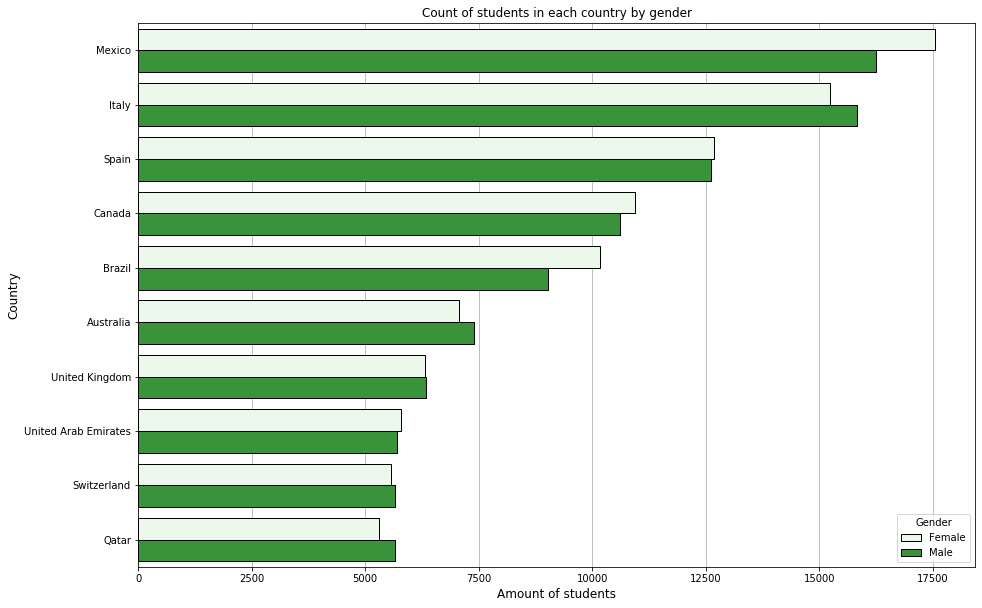

```python
plt.figure(figsize = [15, 10])
axis = plt.subplot(1, 1, 1)
base_colore = sb.color_palette()[2]
order = df_clean['Country'].value_counts().iloc[:10].index

sb.countplot(data = df_clean,  y= 'Country', hue = 'Gender', color = base_color, order = order,edgecolor='black', linewidth=1);
plt.grid(axis='x');
axis.set_axisbelow(True);
plt.xlabel('Amount of students', fontsize=12)
plt.ylabel('Country', fontsize=12)
plt.title('Count of students in each country by gender', fontsize=12)
indexes, labels = plt.yticks()
```

**Observation: The male/female ratio seems to be equilibrated among the highest enrolled countries in the pisa study.**

### Visualization 6 | How are males/females scoring for the 3 different subjects?

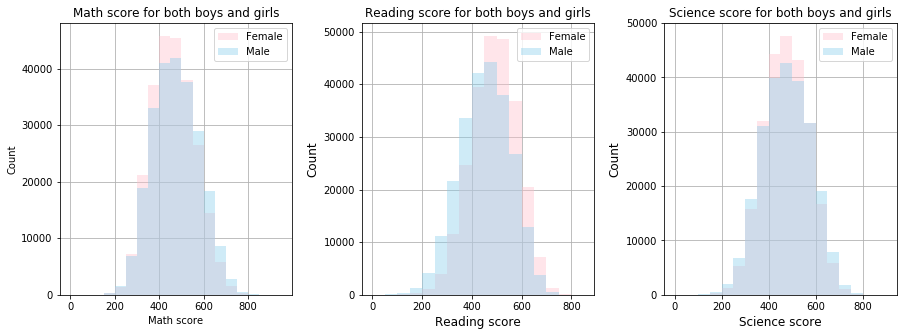

```python
plt.figure(figsize = [15, 5])
plt.subplots_adjust(wspace = 0.3)

#Plot 1 - Math score
axis = plt.subplot(1, 3, 1)
bin_edges = np.arange(0,df_clean['Math_score'].max()+50,50)
plt.hist(data = df_clean.query("Gender=='Female'"), x = 'Math_score',alpha = 0.4 , bins = bin_edges, label = 'Female', color = "pink");
plt.hist(data = df_clean.query("Gender=='Male'"), x = 'Math_score',alpha = 0.4 , bins = bin_edges, label = 'Male', color = "skyblue");
plt.legend();
plt.xlabel('Math score')
plt.ylabel('Count')
plt.title('Math score for both boys and girls')
plt.grid();
axis.set_axisbelow(True);

#Plot 2 - Reading score
axis = plt.subplot(1, 3, 2)
bin_edges = np.arange(0,df_clean['Reading_score'].max()+50,50)
plt.hist(data = df_clean.query("Gender=='Female'"), x = 'Reading_score',alpha = 0.4 , bins = bin_edges, label = 'Female', color = "pink");
plt.hist(data = df_clean.query("Gender=='Male'"), x = 'Reading_score',alpha = 0.4 , bins = bin_edges, label = 'Male', color = "skyblue");
plt.legend();
plt.xlabel('Reading score', fontsize=12)
plt.ylabel('Count', fontsize=12)
plt.title('Reading score for both boys and girls', fontsize=12)
plt.grid();
axis.set_axisbelow(True);


#Plot 3 - Science score
axis = plt.subplot(1, 3, 3)
bin_edges = np.arange(0,df_clean['Science_score'].max()+50,50)
plt.hist(data = df_clean.query("Gender=='Female'"), x = 'Science_score',alpha = 0.4 , bins = bin_edges, label = 'Female', color = "pink");
plt.hist(data = df_clean.query("Gender=='Male'"), x = 'Science_score',alpha = 0.4 , bins = bin_edges, label = 'Male', color = "skyblue");
plt.legend();
plt.xlabel('Science score', fontsize=12)
plt.ylabel('Count', fontsize=12)
plt.title('Science score for both boys and girls', fontsize=12)
plt.grid();
axis.set_axisbelow(True);
```

**Observation: Math score tends to be higher for boys compared to girls in contrast to the reading score where girls seem to get an higher score. The science score seems to be evenly disributed for both boys and girls.**

### Visualization 7 | What are the mean scores for students from different countries for the 3 different subjects?

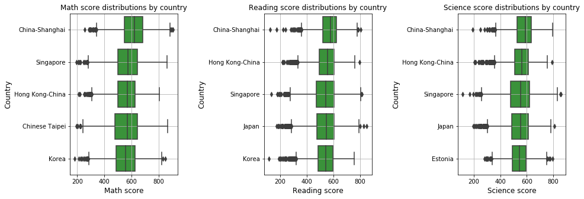

```python
plt.figure(figsize = [15, 5])
plt.subplots_adjust(wspace = 0.8)


#Plot 1 - Math score
plt.subplot(1,3,1)
math_score_by_country = df_clean.groupby('Country')['Math_score'].mean().sort_values(ascending = False).iloc[:5].index
base_colore = sb.color_palette()[2]
sb.boxplot(data = df_clean, x= 'Math_score', y= 'Country',
           order =math_score_by_country, color = base_color );
plt.xlabel('Math score', fontsize=12)
plt.ylabel('Country', fontsize=12)
plt.title('Math score distributions by country', fontsize=12)
plt.grid();
axis.set_axisbelow(True);

#Plot 2 - Reading score
plt.subplot(1,3,2)
reading_score_by_country = df_clean.groupby('Country')['Reading_score'].mean().sort_values(ascending = False).iloc[:5].index
base_colore = sb.color_palette()[2]
sb.boxplot(data = df_clean, x= 'Reading_score', y= 'Country',
           order = reading_score_by_country, color = base_color );
plt.xlabel('Reading score', fontsize=12)
plt.ylabel('Country', fontsize=12)
plt.title('Reading score distributions by country', fontsize=12)
plt.grid();
axis.set_axisbelow(True);


#Plot 3 - Science score

plt.subplot(1,3,3)
science_score_by_country = df_clean.groupby('Country')['Science_score'].mean().sort_values(ascending = False).iloc[:5].index
base_colore = sb.color_palette()[2]
sb.boxplot(data = df_clean, x= 'Science_score', y= 'Country',
           order = science_score_by_country, color = base_color );
plt.xlabel('Science score', fontsize=12)
plt.ylabel('Country', fontsize=12)
plt.title('Science score distributions by country', fontsize=12)
plt.grid();
axis.set_axisbelow(True);
```

### Visualization 8 | What is the gender distribution in the top 90,95,99th percentile of students?

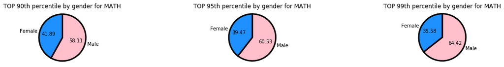

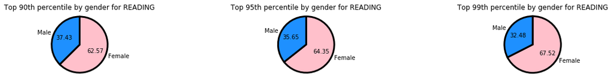

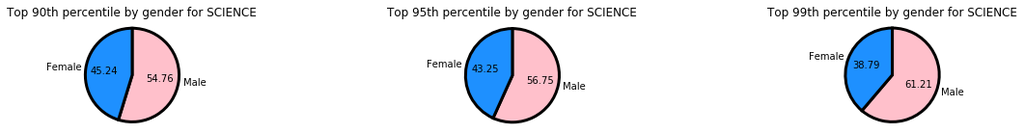

```python
fig, ax=plt.subplots(nrows=1, ncols=3, figsize=(20,2))
plt.subplots_adjust(hspace = 0.3)

df_math_90 = df_clean.query('Math_score>=@df_clean.Math_score.quantile(.90)')
df_math_95 = df_clean.query('Math_score>=@df_clean.Math_score.quantile(.95)')
df_math_99 = df_clean.query('Math_score>=@df_clean.Math_score.quantile(.99)')

percent=[90,95,99]
ax=ax.flatten()
for i in range(3):
    plt.sca(ax[i])
    df=eval('df_math_'+str(percent[i]))
    plt.pie(df['Gender'].value_counts(), labels=df['Gender'].value_counts().index
            ,startangle=90,counterclock=False,autopct='%.2f', textprops={'fontsize': 10},
           colors = ['pink','dodgerblue'], wedgeprops={"edgecolor":"k",'linewidth': 3} )
    plt.axis('square')
    plt.title('TOP '+ str(percent[i])+'th percentile by gender for MATH', fontsize=12)


fig, ax=plt.subplots(nrows=1, ncols=3, figsize=(20,2))
plt.subplots_adjust(hspace = 0.3)
df_reading_90=df_clean.query('Reading_score>=@df_clean.Reading_score.quantile(.90)')
df_reading_95=df_clean.query('Reading_score>=@df_clean.Reading_score.quantile(.95)')
df_reading_99=df_clean.query('Reading_score>=@df_clean.Reading_score.quantile(.99)')

percent=[90,95,99]
ax=ax.flatten()
for i in range(3):
    plt.sca(ax[i])
    df=eval('df_reading_'+str(percent[i]))
    plt.pie(df['Gender'].value_counts(), labels=df['Gender'].value_counts().index
            ,startangle=90,counterclock=False,autopct='%.2f', textprops={'fontsize': 10},
           colors = ['pink','dodgerblue'], wedgeprops={"edgecolor":"k",'linewidth': 3})
    plt.axis('square')
    plt.title('Top '+ str(percent[i])+'th percentile by gender for READING', fontsize=12)


df_science_90=df_clean.query('Science_score>=@df_clean.Reading_score.quantile(.90)')
df_science_95=df_clean.query('Science_score>=@df_clean.Reading_score.quantile(.95)')
df_science_99=df_clean.query('Science_score>=@df_clean.Reading_score.quantile(.99)')


fig, ax=plt.subplots(nrows=1, ncols=3, figsize=(20,2))
plt.subplots_adjust(hspace = 0.3)
percent=[90,95,99]
ax=ax.flatten()
for i in range(3):
    plt.sca(ax[i])
    df=eval('df_science_'+str(percent[i]))
    plt.pie(df['Gender'].value_counts(), labels=df['Gender'].value_counts().index
            ,startangle=90,counterclock=False,autopct='%.2f', textprops={'fontsize': 10},
           colors = ['pink','dodgerblue'], wedgeprops={"edgecolor":"k",'linewidth': 3} )
    plt.axis('square')
    plt.title('Top '+ str(percent[i])+'th percentile by gender for SCIENCE', fontsize=12)
```

**Observation: The gender distribution is dependant on the subject. Both in science and mathematics, going towards a higher percentile, more boys achieved a higher scores whereas in reading, more girls obtained a higher score going to the higest percentile of scores.**

### Visualization 9 | Are students who score high on one subject are likely to score high on another subject?

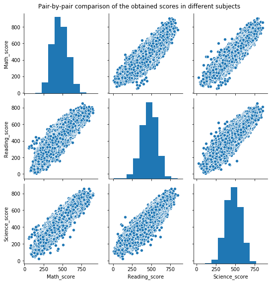

```python
grid = sb.pairplot(data = df_clean, vars=["Math_score", "Reading_score", "Science_score"]);
grid.fig.suptitle("Pair-by-pair comparison of the obtained scores in different subjects", y = 1.03);
```

**Observation: There is a positive correlation between scores of different subject.**

### Visualization 10 | Does the highest degree of the parents have an influence on the mean scores of the student for the 3 individual subjects?

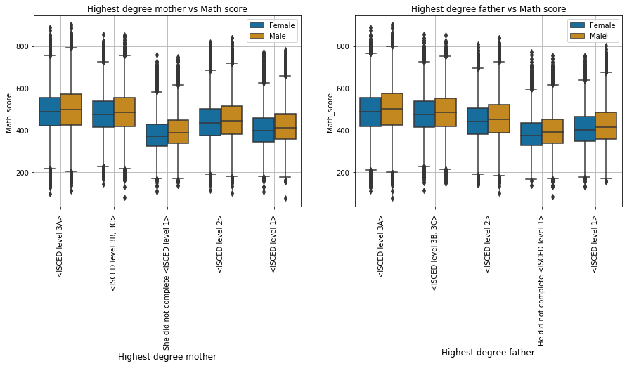

```python
plt.figure(figsize = [15, 5])
plt.subplots_adjust(hspace = 1)


plt.subplot(1,2,1)
axis = sb.boxplot(x='Highest_degree_mother', y='Math_score',hue = 'Gender', data=df_clean, palette="colorblind" )
plt.xticks(rotation=90);
plt.grid();
axis.set_axisbelow(True);
plt.title('Highest degree mother vs Math score');
plt.xlabel('Highest degree mother', fontsize = 12);
axis.legend( loc='upper right');

plt.subplot(1,2,2)
axis = sb.boxplot(x='Highest_degree_father', y='Math_score',hue = 'Gender', data=df_clean, palette="colorblind" )
plt.xticks(rotation=90);
plt.grid();
axis.set_axisbelow(True);
plt.title('Highest degree father vs Math score');
plt.xlabel('Highest degree father', fontsize = 12);
axis.legend( loc='upper right');
```

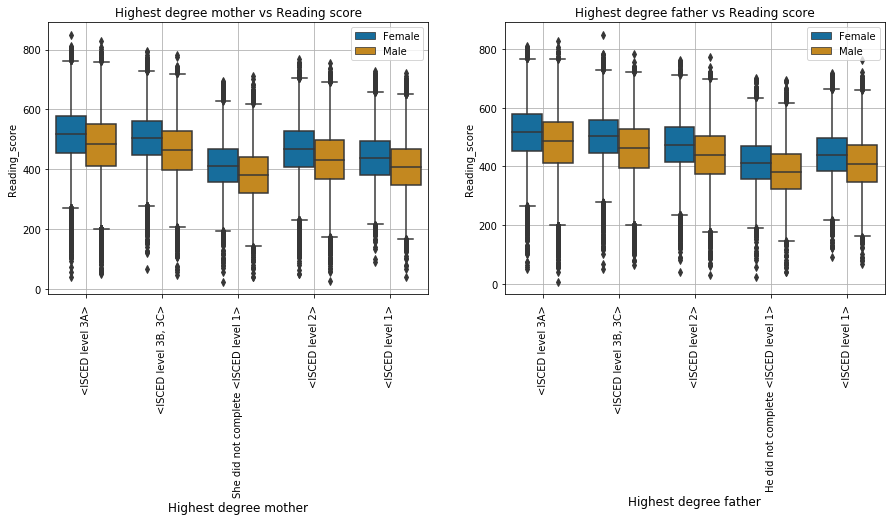

```python
plt.figure(figsize = [15, 5])
plt.subplots_adjust(hspace = 1)


plt.subplot(1,2,1)
axis = sb.boxplot(x='Highest_degree_mother', y='Reading_score',hue = 'Gender', data=df_clean, palette="colorblind" )
plt.xticks(rotation=90);
plt.grid();
axis.set_axisbelow(True);
plt.title('Highest degree mother vs Reading score');
plt.xlabel('Highest degree mother', fontsize = 12);
axis.legend( loc='upper right');

plt.subplot(1,2,2)
axis = sb.boxplot(x='Highest_degree_father', y='Reading_score',hue = 'Gender', data=df_clean, palette="colorblind" )
plt.xticks(rotation=90);
plt.grid();
axis.set_axisbelow(True);
plt.title('Highest degree father vs Reading score');
plt.xlabel('Highest degree father', fontsize = 12);
axis.legend( loc='upper right');
```

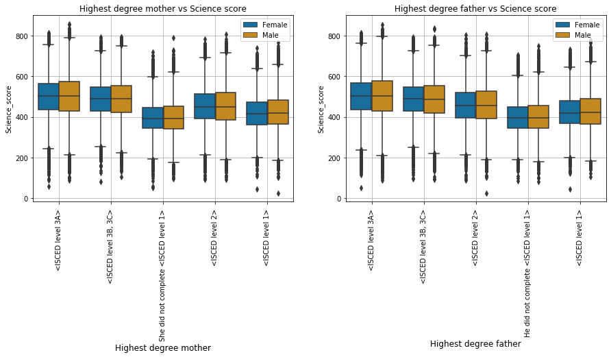

```python
plt.figure(figsize = [15, 5])
plt.subplots_adjust(hspace = 1)

plt.subplot(1,2,1)
axis = sb.boxplot(x='Highest_degree_mother', y='Science_score',hue = 'Gender', data=df_clean, palette="colorblind" )
plt.xticks(rotation=90);
plt.grid();
axis.set_axisbelow(True);
plt.title('Highest degree mother vs Science score');
plt.xlabel('Highest degree mother', fontsize = 12);
axis.legend( loc='upper right');

plt.subplot(1,2,2)
axis = sb.boxplot(x='Highest_degree_father', y='Science_score',hue = 'Gender', data=df_clean, palette="colorblind" )
plt.xticks(rotation=90);
plt.grid();
axis.set_axisbelow(True)
plt.title('Highest degree father vs Science score');
plt.xlabel('Highest degree father', fontsize = 12);
axis.legend( loc='upper right');
```

**Observation: If either the mother or the father obtained no degree or the lowest degree (<ISCED level 1), lower mean scores are observed for the students in all 3 domains. No striking difference in mean scores of 3 subjects are observed between higher obtained degrees of either the mother or the father. There is however the tendency that higher educated parents have childeren with higher mean scores for all three subjects.**